# final_exam

Dan Gause

5/14/2020

## Question 1

Here we are deciding whether or not there is a statistical difference in average “happiness” between Alex and Shannon for this one week period. We are now making the claim that these two samples are actually matched pairs, not independent. We are claiming this for a number of reasons - some days suck more overall (mondays) and some are better overall (saturdays). Additionally, the happiness level of one spouse may affect the happiness level of the other (this could be an inverse relationship, but lets hope not). Thus we only have one variable, the happiness difference between Alex and Shannon each day. Let’s now perform a 95% bootstrap percentile confidence interval for the mean happiness difference.

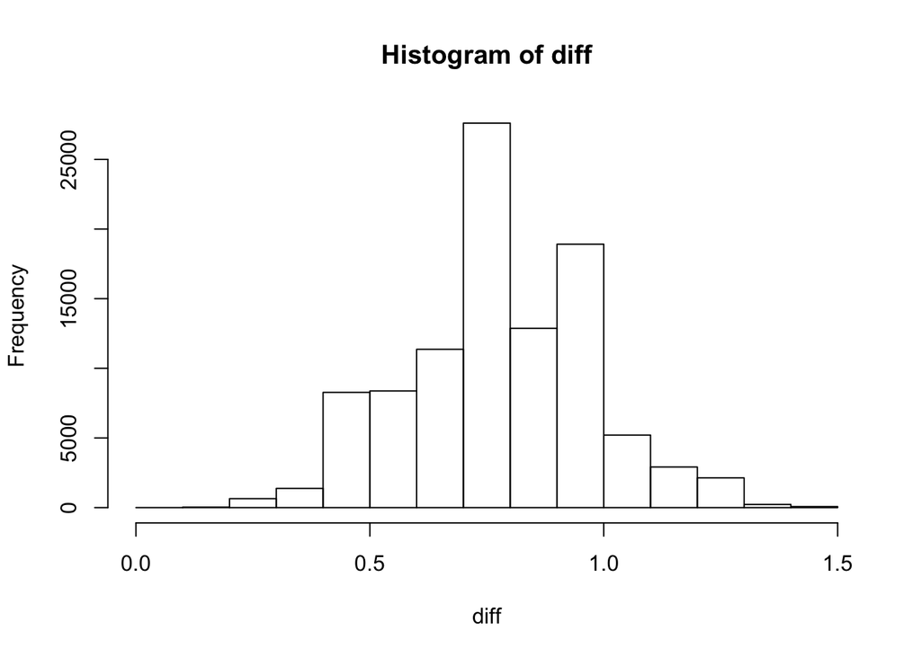

```r
happiness <- c(4, 3.5, 5, 4.5, 2, 5, 5) - c(2.5, 3, 4.5, 3, 1, 4.5, 5)

N <- 10^5
sample.vec <- numeric(7)
diff <- numeric(N)

for(i in 1:N){
  sample.vec <- sample(happiness, 7, replace = TRUE)
  diff[i] <- mean(sample.vec)
}

hist(diff)
```

```r
mean.diff <- mean(diff)
interval <- quantile(diff, c(0.025, 0.975))
```

We found that after performing a one sample bootstrap with 10^5 resamples, there is a 95% bootstrap percentile interval for teh mean price difference to be (0.4285714, 1.1428571). The bootstrap mean was 0.7852407. Seeing as zero is not included in this interval, we conclude that there is a mean happiness difference between Alex and Shannon, namely that Alex is happier overall than Shannon.

## Question 2

Let’s assume that Alex, statistical as he is, decides to only accuse Rick of cheating if he is 95% confident that the die is biased. Seeing as he doesn’t know the nature of the biased die, he is informing his decision based on how improbable it is to observe the number of die rolls for a fair die. Here, the null hypothesis, ($H_0$), is that the die is fair, and the alternate hypothesis, ($H_a$), is that the die is biased. After watching Rick roll, he suspects the die to be weighted towards 8s. We know that the probability of rolling an 8 is $\frac{1}{2}*\frac{1}{8} + \frac{1}{2}*\frac{1}{2} = \frac{5}{16}$ as the probability of the die being either fair or biased is $\frac{1}{2}$. For example, for $n=10$, Alex would reject $H_0$ if he saw 4 or more 8’s rolled as dbinom(4,10,1/8) = 0.023 < 0.05. Yet we know that the probability of rolling 4 or more 8’s out of 10 rolls is actually 1/2(dbinom(4,10,1/8)+dbinom(4,10,5/16)) = 0.1172. Thus, if Alex rejected the null hypothesis based on seeing 4 8’s out of 10 rolls, there would be a 11.72% chance that he committed a type I error. Now, the expectation value for the overall emotional change is the sums of the probabilities of the four events multiplied by their emotional change value. The probabilities for each of the four events depend on the number of rolls, $n$. Let’s calculate the probabilities for each of the four events for a handful of values of $n$.

```r
N <- 50
emotion <- numeric(N)

for (i in 2:N){
  first.k <- ceiling(i/8)
  alex.vec <- dbinom(c(1:i),i, 1/8)
  min.k <- head(which(alex.vec[-c(1:first.k)] < 0.05),1)

  typeI <- sum(dbinom(c(min.k:i),i,5/16))
  trueNeg <- 1 - typeI

  typeII <- sum(dbinom(c(i:min.k), i, 5/16))
  truePos <- 1 - typeII

  emotion[i] <- -1*i +200*trueNeg - 100*typeI + 50*truePos - 50*typeII
}
max.emotion <<- max(emotion)
ideal.roll <<- which.max(emotion)+1
```

We found that the ideal number of rolls was 5, which gave an expected emotional change value of positive 97.8371582.

## Question 3

We are now trying to determine whether or not there is a difference in the mean weight of baby chickens for various feed types. To do this, we will compare the difference in means of the weights of each feed group of chickens with a 2-sample t-test. This entails 6 choose 2 = 15 t-tests. Thus, to uphold an overall $\alpha$ of 0.95, we will adjust the p-value for each test using the conservative Bonferroni method. Now we compute each t-test using pairwise_t_test() and for each of these adjusted p-values, we need to consider both tails of the distribution, so we multiply each value by 2. Our null hypothesis is that there is no significant difference between mean weights between feed groups.

```r
ttests <- chickwts %>%
   pairwise_t_test(weight ~ feed, p.adjust.method = "bonferroni", paired = FALSE)
significants <- which(2*ttests$p.adj < .05)
data.frame(group1 =ttests$group1[significants], group2 = ttests$group2[significants])
```

```
##      group1    group2
## 1    casein horsebean
## 2    casein   linseed
## 3    casein   soybean
## 4 horsebean  meatmeal
## 5 horsebean   soybean
## 6 horsebean sunflower
## 7   linseed sunflower
## 8   soybean sunflower
```

We can see that there is significant differences between mean weights for some of these different feed groups. The horsebean feed group differed significantly from 4 other feed groups, the casein feed group differed significantly from 3 other feed groups, and the sunflower feed group differed significantly from 3 other feed groups. Thus, we reject our null hypothesis with 95% confidence, concluding that there is a difference between mean weights of some different feed groups.

Additionally, I chose not to bootstrap the t-confidence intervals because there is a relatively low sample size (n !>> 10).

## Question 4

We now determine whether a linear model is appropriate in predicting hits as a function of stolen bases. To decide the validity of linear regression, we need to check our assumptions that there is a linear trend in the data, and the residuals are normally distributed with mean 0 and constant variance. Let us take an initial look at the data.

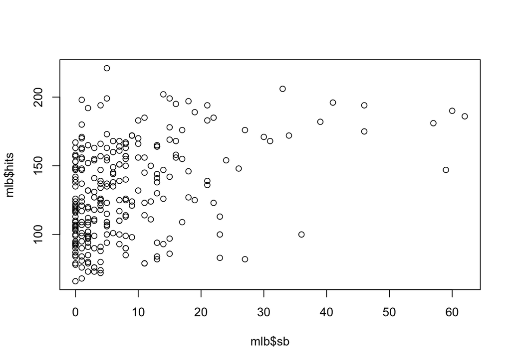

```r
mlb <- data.frame(hits = Batters2005$Hits, sb = Batters2005$SB,
                  loghits = log(Batters2005$Hits), logsb = log(Batters2005$SB))
plot(mlb$sb, mlb$hits)
```

This plot is not very convincing in arguing for a linear model. It makes it difficult to analyze because the density of observations is much higher for lower stolen bases. There is relatively high hits for the handful of observations with sb > 30. If anything, the trend looks slightly logarithmic in nature. Let’s check for logarithmic behavior.

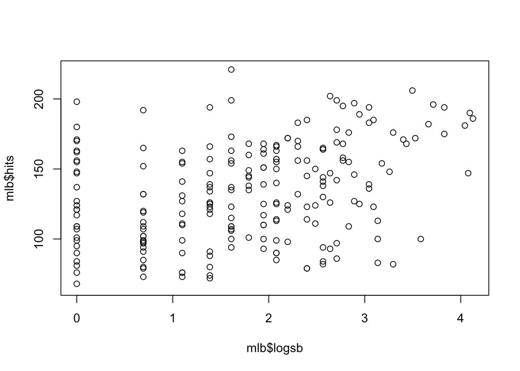

```r
plot(mlb$logsb, mlb$hits)
```

Now let’s built the linear model and look at some residual plots.

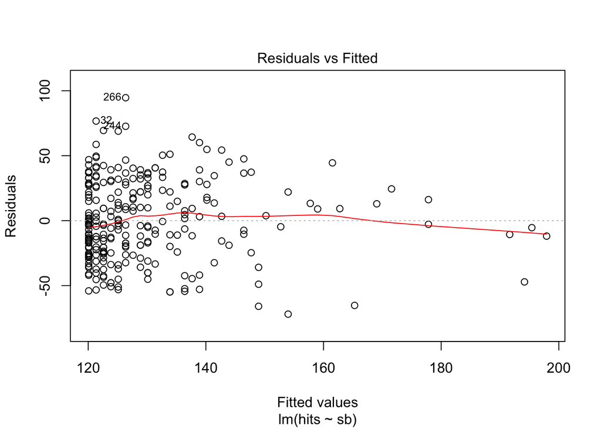

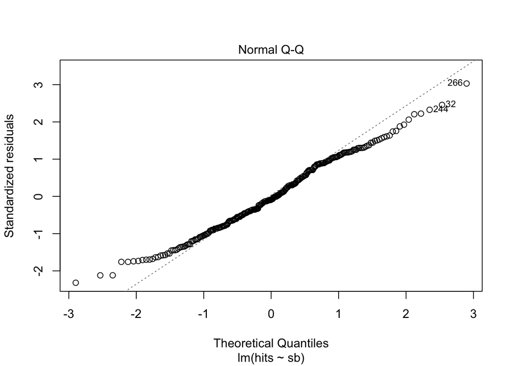

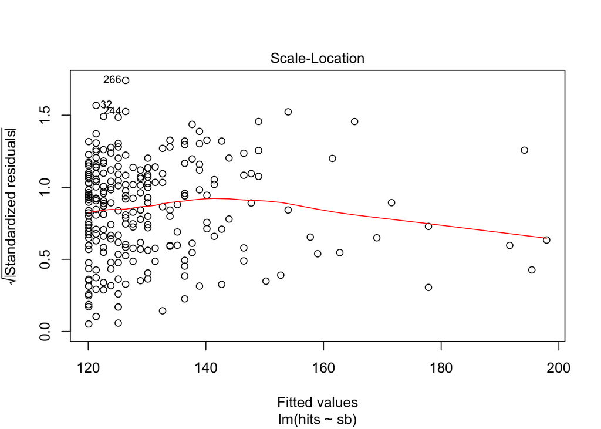

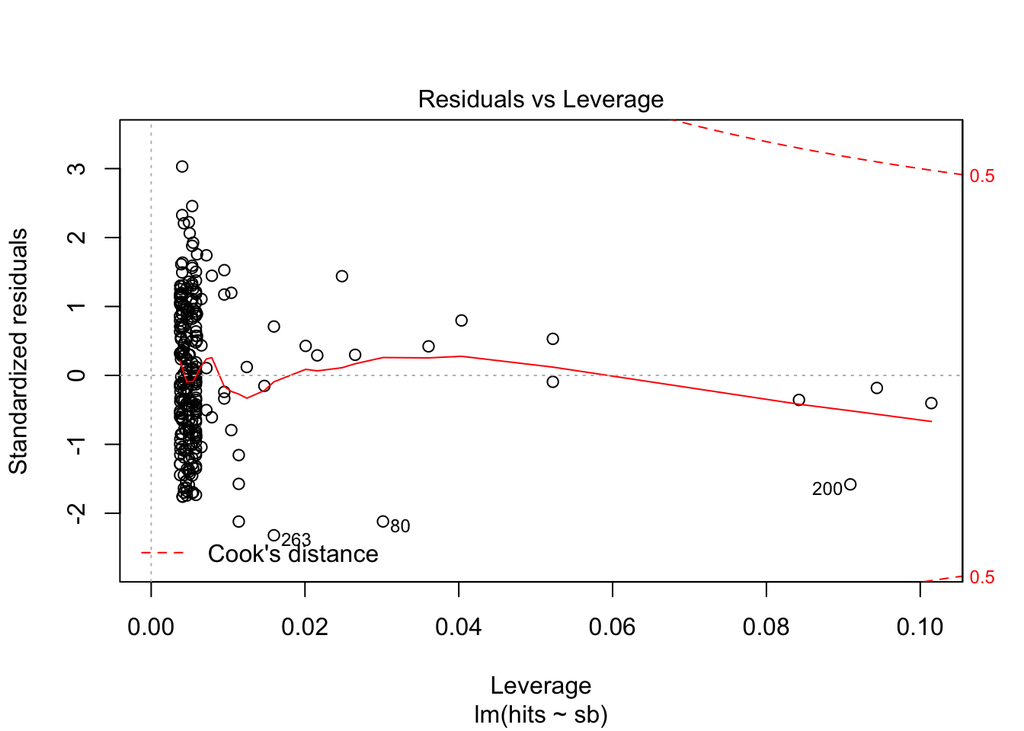

```r
lm1 <- lm(hits ~ sb,
   data = mlb)
plot(lm1)
```

Indeed, in observing the residuals vs fitted plot, the residuals do appear normally distributed with mean 0, though less so for higher fitted values. The variance appears fairly constant across the fitted values, except for the highest quantile. In observing the Q-Q plot, we see that the tails of the distribution splay away. The standardized residuals are lower in magnitude for higher magnitude quantiles than they should be for a good LM fit. Finally, in observing the residuals vs leverage plot, we can see that the higher points hold a lot of leverage, which is not good evidence for a LM fit.

Overall, there is not a clear linear dependency of hits on stolen bases, although the residuals for the LM appear fairly normally distributed. I would not recommend linear regression for this data, and am not confident in a linear models predictive power.

## Question 5

We are sampling from a population that we know to be heavily right-skewed. Off the bat, we know that the bootstrap percentile interval and bootstrap t interval are in general asymmetrical, and estimate the skewness of a population from the skewness of the sample, while classical t intervals assume that the population has no underlying skewness. Our decision for which confidence interval method to use is heavily dependent on our sample size. The sample size gives us a measure of how much trust we can put in our data, vs how much classical inference and assumptions we should make. With a higher sample size, we can put more trust in our data, in which case the bootstrap t-confidence interval is the best choice. The bootstrap t method makes the largest skewness correction, and with a large sample size, handles skew the best. On the other hand, it is more variable than a single t-confidence interval or a bootstrap percentile interval, so if the sample size is smaller, we should consider our other options. Now if we have smaller sample size, I would be more apt to use a bootstrap percentile interval as it is less variable than the bootstrap t. If we have a very small sample size, skewness cannot be estimately accurately from the sample, so only then would I suggest using a t-confidence interval. Although this wrongly assumes there is no skewness, it could be better than using an estimate that has high variability.

## Question 6

Calculate the MLE of $\beta$ for $Y_i = \beta X_i + \epsilon_i$. The likelihood function is $L(y_i|x_i, \beta, \sigma) = f(y_1|x_1)...f(y_n|x_n) = \prod\limits_{i=1}^{n} \frac{1}{\sqrt{2 \pi} \sigma} e^{\frac{-(y_i-\beta x_i)^2}{2 \sigma^2}} = \left( \frac{1}{\sqrt{2 \pi} \sigma} \right)^n e^{-\frac{1}{2 \sigma^2} \sum(y_i - \beta x_i)^2}$. Now, by taking the logarithm of the likelihood function $\log L = -n \log (\sqrt{2 \pi \sigma}) - \frac{1}{2 \sigma^2}\sum(y_i - \beta x_i)^2$, so by taking the derivative with respect to $\beta$ and setting it equal to zero, we arrive at $0 = -\frac{1}{\sigma^2} \sum(y_i-\beta x_i)(x_i)$, and by solving for $\beta$ we see that $\hat{\beta} = \frac{\sum x_i y_i}{\sum x_i^2}$.

Now, to check if $\hat{\beta}$ is biased, lets find the expectation value. $\mathbb{E}[\hat{\beta}] = \mathbb{E}[\frac{\sum X_i Y_i}{\sum X_i^2}] = \frac{\sum X_i \mathbb{E}[Y_i]}{\sum X_i^2} = \frac{\sum X_i (\beta X_i)}{\sum X_i^2} = \beta$. Thus, $\mathbb{E}[\hat{\beta}] - \beta = 0$, so $\hat{\beta}$ is an unbiased estimator.